# Group13_BUDT704_Project_Update

## BUDT704 Team Project (0502) Group 13 - Team Story Sharks From Pitch to Payout: A Deep Dive into All Shark Tank Pitches

[figure not shown]

Source : https://cdn1.edgedatg.com/

## **Project Overview**

Shark Tank 🦈 is a reality TV show which showcases startups pitching their ideas to wealthy investors (the “Sharks'') aiming to convince them to invest in their startup. Over the years, the show has gained immense popularity amongst its viewers and keeps growing its user base year on year. Why? Because there is so much DRAMA. Most of these curated start-ups have something called the “cocktail party factor”, where everyone has an opinion about these businesses, which makes the show all the more relatable. Each year, the show is aired for a “Season” showcasing various start-up pitching for investments. Although the pitch is recorded long before it is aired, the airing of the pitch acts as a sweepstakes marketing campaign for the startups. Whilst pitching it to potential investors, the airing of the show makes it a pitch to their potential customers. The Shark Tank franchise is huge and spans across various countries. Although we love watching all of those shows, we’re going to focus on the iconic **US Shark Tank.**  
The **Sharks** mentioned in the dataset are **Barbara Corcoran, Mark Cuban, Lori Greiner, Robert Herjavec, Daymond John and Kevin O Leary.**  
Our objective is to proficiently process, analyze, and visualize data from diverse datasets, enabling us to extract valuable insights regarding patterns, behavior, pitch outcomes, temporal trends, and market intelligence.  
We also aim to cover how this analysis will be useful, how the knowledge gained can be applied in real life and why this analysis was needed to be done.  
As the team name DATA SHARKS suggests, we aim to fish the story out of these datasets and be able to finally understand the ultimate learning from this course - 'TELL ME A STORY!'.  
At the end of it, we're gonna be like - "You're gonna need a bigger Jupyter Notebook!"

## **Research Questions**

**Question 1:**  
Can we identify temporal patterns in pitch success on the show and how do they evolve over the seasons, including viewership trends?  
**Question 2:**  
Are there statistically significant co-investment patterns among the sharks, revealing insights into their investment strategies and price discrimination?  
**Question 3:**  
Can we analyze trends in pitchers on the show to identify sectors with the highest capital raised and assess how investment trends impact the business pitches?  
**Question 4:**  
What factors in Business pitches influence the equity demands of sharks on the show and to what extent do these descriptions impact the likelihood of securing a deal?  
**Question 5:**  
Does the presence of specific investors or guests on the show influence entrepreneurs' deal success and viewership, and who has the most significant impact on both?

## **Project Milestones**

**1 - Data Collection ✅**  
1.1 - Importing Libraries  
1.2 - Importing Datasets  
**2 - Exploratory Data Analysis ✅**  
**3 - Data Preprocessing ⌛**  
3.1 - Data Cleaning  
3.2 - Data Transformation  
**4 - Data Analysis ⌛**  
Answering 5 data analysis based questions, including observations, inferences and comments about the working of the code.

**5 - Data Visualization ⌛**  
Based on the questions listed above to gain a better understanding of the data & gain more inferences  
**6 - Data Modeling** - Implementing ML Models for predictive analysis or classification  
**7 - Conclusion** - Knowledge gained from this project and its relation to the business world  
**8 - Limitations and Future Research**

### **Progress Tracker**

| Tasks | Progress |
| --- | --- |
| Task 1 | 100% |
| Task 2 | 100% |
| Task 3 | 85% |
| Task 4 | 30% |
| Task 5 | 20% |
| Task 6 | 0% |
| Task 7 | 0% |
| Task 8 | 0% |

**Notes from the Team:**

- We have updated and refined the Project Overview and revised our questions and scope as well. We have tried to cater to all of the valuable feedback that was given to us.
- The dataset 2 requires text processing, due to which, the data cleaning task for this becomes more complex. Therefore, it shall be covered when the team touches upon the Question 4.
- As per the timeline in our project proposal, we are almost done with Question 1 and have touched upon Question 2. Our team will ensure that the timeline is followed. Addtionally, our team has decided that we will not be pursuing the machine learning aspect. From the initial data exploration that the team had performed, we inferred that performing ML on this dataset shall not create much impact and give meaningful results. We have found that we can answer our research questions without the use of ML.
- Final touches will be given to the entire notebook before the final project showcase and report on 4th Dec.

## 1 **Data Collection**

The datasets are acquired from : **Kaggle** (https://www.kaggle.com/)

### 1.1 Import Required Libraries

```python
import pandas as pd
import numpy as np
import re
from datetime import datetime
import matplotlib.pyplot as plt
import seaborn as sns
import plotly
import plotly.graph_objects as go
import plotly.express as px
from wordcloud import WordCloud
```

```python
print("Notebook last executed on:", datetime.now().strftime("%m/%d/%Y, %H:%M:%S"))
```

```
Notebook last executed on: 12/01/2023, 13:59:05
```

### 1.2 Importing the first dataset

```python
# import data from csv file present in GitHub repository using pandas
path = 'https://raw.githubusercontent.com/JoyceGaoH/project-shark/main/Shark%20Tank%20US%20dataset.csv' # save github repository url
df_shark_tank_1 = pd.read_csv(path)
df_shark_tank_1.head()
```

|  | Season Number | Season Start | Season End | Episode Number | Pitch Number | Original Air Date | Startup Name | Industry | Business Description | Pitchers Gender | ... | Kevin O Leary Investment Equity | Guest Investment Amount | Guest Investment Equity | Guest Name | Barbara Corcoran Present | Mark Cuban Present | Lori Greiner Present | Robert Herjavec Present | Daymond John Present | Kevin O Leary Present |
| --- | --- | --- | --- | --- | --- | --- | --- | --- | --- | --- | --- | --- | --- | --- | --- | --- | --- | --- | --- | --- | --- |
| 0 | 1 | 9-Aug-09 | 5-Feb-10 | 1 | 1 | 9-Aug-09 | AvaTheElephant | Health/Wellness | Ava The Elephant - Baby and Child Care | Female | ... | NaN | NaN | NaN | NaN | 1.0 | 0.0 | 0.0 | 1.0 | 1.0 | 1.0 |
| 1 | 1 | 9-Aug-09 | 5-Feb-10 | 1 | 2 | 9-Aug-09 | Mr.Tod'sPieFactory | Food and Beverage | Mr. Tod's Pie Factory - Specialty Food | Male | ... | NaN | NaN | NaN | NaN | 1.0 | 0.0 | 0.0 | 1.0 | 1.0 | 1.0 |
| 2 | 1 | 9-Aug-09 | 5-Feb-10 | 1 | 3 | 9-Aug-09 | Wispots | Business Services | Wispots - Consumer Services | Male | ... | NaN | NaN | NaN | NaN | 1.0 | 0.0 | 0.0 | 1.0 | 1.0 | 1.0 |
| 3 | 1 | 9-Aug-09 | 5-Feb-10 | 1 | 4 | 9-Aug-09 | CollegeFoxesPackingBoxes | Lifestyle/Home | College Foxes Packing Boxes - Consumer Services | Male | ... | NaN | NaN | NaN | NaN | 1.0 | 0.0 | 0.0 | 1.0 | 1.0 | 1.0 |
| 4 | 1 | 9-Aug-09 | 5-Feb-10 | 1 | 5 | 9-Aug-09 | IonicEar | Software/Tech | Ionic Ear - Novelties | Male | ... | NaN | NaN | NaN | NaN | 1.0 | 0.0 | 0.0 | 1.0 | 1.0 | 1.0 |

5 rows × 50 columns

### 1.2 import the second dataset:

```python
path2 = 'https://raw.githubusercontent.com/JoyceGaoH/project-shark/main/Sharktankpitchesdeals.csv'
df_shark_tank_2 = pd.read_csv(path2)
df_shark_tank_2.head()
```

|  | Season_Epi_code | Pitched_Business_Identifier | Pitched_Business_Desc | Deal_Status | Deal_Shark |
| --- | --- | --- | --- | --- | --- |
| 0 | 826 | Bridal Buddy | a functional slip worn under a wedding gown th... | 1 | KOL+LG |
| 1 | 826 | Laid Brand | hair-care products made with pheromones . Laid... | 0 | NaN |
| 2 | 826 | Rocketbook | a notebook that can scan contents to cloud ser... | 0 | NaN |
| 3 | 826 | Wine & Design | painting classes with wine served . Wine & Des... | 1 | KOL |
| 4 | 824 | Peoples Design | a mixing bowl with a built-in scoop . Peoples ... | 1 | LG |

## 2 **Exploratory Data Analysis**

```python
df_shark_tank_1.shape
```

```
(1274, 50)
```

```python
df_shark_tank_2.shape
```

```
(706, 5)
```

The second datasets seems to have lesser number of observations as comapred to the first one. We observed that the 2nd dataset has records for 8 seasons, whereas, the 1st datasets has records for 14.

```python
df_shark_tank_1.columns
```

```
Index(['Season Number', 'Season Start', 'Season End', 'Episode Number',
       'Pitch Number', 'Original Air Date', 'Startup Name', 'Industry',
       'Business Description', 'Pitchers Gender', 'Pitchers City',
       'Pitchers State', 'Pitchers Average Age', 'Entrepreneur Names',
       'Company Website', 'Multiple Entrepreneurs', 'US Viewership',
       'Original Ask Amount', 'Original Offered Equity', 'Valuation Requested',
       'Got Deal', 'Total Deal Amount', 'Total Deal Equity', 'Deal Valuation',
       'Number of sharks in deal', 'Investment Amount Per Shark',
       'Equity Per Shark', 'Royalty Deal', 'Loan',
       'Barbara Corcoran Investment Amount',
       'Barbara Corcoran Investment Equity', 'Mark Cuban Investment Amount',
       'Mark Cuban Investment Equity', 'Lori Greiner Investment Amount',
       'Lori Greiner Investment Equity', 'Robert Herjavec Investment Amount',
       'Robert Herjavec Investment Equity', 'Daymond John Investment Amount',
       'Daymond John Investment Equity', 'Kevin O Leary Investment Amount',
       'Kevin O Leary Investment Equity', 'Guest Investment Amount',
       'Guest Investment Equity', 'Guest Name', 'Barbara Corcoran Present',
       'Mark Cuban Present', 'Lori Greiner Present', 'Robert Herjavec Present',
       'Daymond John Present', 'Kevin O Leary Present'],
      dtype='object')
```

```python
df_shark_tank_2.columns
```

```
Index(['Season_Epi_code', 'Pitched_Business_Identifier',
       'Pitched_Business_Desc', 'Deal_Status', 'Deal_Shark'],
      dtype='object')
```

```python
df_shark_tank_1.info()
```

```
<class 'pandas.core.frame.DataFrame'>
RangeIndex: 1274 entries, 0 to 1273
Data columns (total 50 columns):
 #   Column                              Non-Null Count  Dtype
---  ------                              --------------  -----
 0   Season Number                       1274 non-null   int64
 1   Season Start                        1274 non-null   object
 2   Season End                          1274 non-null   object
 3   Episode Number                      1274 non-null   int64
 4   Pitch Number                        1274 non-null   int64
 5   Original Air Date                   1274 non-null   object
 6   Startup Name                        1274 non-null   object
 7   Industry                            1274 non-null   object
 8   Business Description                1274 non-null   object
 9   Pitchers Gender                     1267 non-null   object
```

[output cut: 42 more lines]

**A deep-dive into the dataset's columns:**

1. Journey across Seasons

The journey begins by navigating through different seasons, with each season having their own sets of challenges, successes and new learnings. We discover how the atmosphere of entrepreneurial initiatives evolves over time.

1. Enterpreneurial Profiles

The world of entrepreneurship is full of diverse personalities, each with an unique history. 'Pitchers Gender,' 'Pitchers City,' and 'Pitchers State' depict a clear image of the entrepreneurs, highlighting the gender and geographic diversity of people looking to create an impact.

1. Investment Strategies

Pitches that are successful emphasize strategic financial moves and the skillful negotiations to get investments by the enterpreneurs.

1. Dynamics of the Sharks

Shark engagement, visible by their presence, highlights the strategic partnerships that investors and entrepreneurs build, which have an impact on business prospects.

1. Financial Achievements

The results of the show gives insights about the business profiles as well as the difficulties entrepreneurs face when seeking investment, providing information about the difficulties faced by businesses in the real world.

```python
df_shark_tank_2.info()
```

```
<class 'pandas.core.frame.DataFrame'>
RangeIndex: 706 entries, 0 to 705
Data columns (total 5 columns):
 #   Column                       Non-Null Count  Dtype
---  ------                       --------------  -----
 0   Season_Epi_code              706 non-null    int64
 1   Pitched_Business_Identifier  706 non-null    object
 2   Pitched_Business_Desc        706 non-null    object
 3   Deal_Status                  706 non-null    int64
 4   Deal_Shark                   383 non-null    object
dtypes: int64(2), object(3)
memory usage: 27.7+ KB
```

**A brief look into the 2nd dataset's columns:**

- Through their unique personalities, entrepreneurs share a variety of innovative and ambitious stories in the lively episodes of Shark Tank. A fascinating story of entrepreneurial determination is created as deals are secured and strategic partnerships are formed.

```python
df_shark_tank_1.describe().applymap('{:,.2f}'.format)
```

|  | Season Number | Episode Number | Pitch Number | Multiple Entrepreneurs | US Viewership | Original Ask Amount | Original Offered Equity | Valuation Requested | Got Deal | Total Deal Amount | ... | Kevin O Leary Investment Amount | Kevin O Leary Investment Equity | Guest Investment Amount | Guest Investment Equity | Barbara Corcoran Present | Mark Cuban Present | Lori Greiner Present | Robert Herjavec Present | Daymond John Present | Kevin O Leary Present |
| --- | --- | --- | --- | --- | --- | --- | --- | --- | --- | --- | --- | --- | --- | --- | --- | --- | --- | --- | --- | --- | --- |
| count | 1,274.00 | 1,274.00 | 1,274.00 | 847.00 | 1,274.00 | 1,274.00 | 1,274.00 | 1,274.00 | 1,274.00 | 765.00 | ... | 117.00 | 117.00 | 105.00 | 105.00 | 898.00 | 901.00 | 901.00 | 897.00 | 898.00 | 898.00 |
| mean | 7.92 | 12.52 | 637.50 | 0.44 | 5.14 | 284,137.36 | 13.80 | 3,550,595.48 | 0.60 | 296,062.96 | ... | 240,747.86 | 15.11 | 212,293.65 | 15.59 | 0.56 | 0.90 | 0.75 | 0.88 | 0.66 | 0.96 |
| std | 3.72 | 7.47 | 367.92 | 0.50 | 1.48 | 359,005.10 | 8.64 | 5,878,462.11 | 0.49 | 358,828.25 | ... | 300,652.14 | 11.23 | 211,753.55 | 13.35 | 0.50 | 0.30 | 0.43 | 0.33 | 0.47 | 0.21 |
| min | 1.00 | 1.00 | 1.00 | 0.00 | 2.27 | 10,000.00 | 1.00 | 40,000.00 | 0.00 | 10,000.00 | ... | 20,000.00 | 0.00 | 20,000.00 | 0.00 | 0.00 | 0.00 | 0.00 | 0.00 | 0.00 | 0.00 |
| 25% | 5.00 | 6.00 | 319.25 | 0.00 | 3.85 | 100,000.00 | 10.00 | 666,667.00 | 0.00 | 100,000.00 | ... | 83,333.33 | 6.00 | 75,000.00 | 8.75 | 0.00 | 1.00 | 1.00 | 1.00 | 0.00 | 1.00 |
| 50% | 8.00 | 12.00 | 637.50 | 0.00 | 4.88 | 200,000.00 | 10.00 | 1,500,000.00 | 1.00 | 200,000.00 | ... | 150,000.00 | 10.00 | 125,000.00 | 11.00 | 1.00 | 1.00 | 1.00 | 1.00 | 1.00 | 1.00 |
| 75% | 11.00 | 19.00 | 955.75 | 1.00 | 6.39 | 350,000.00 | 20.00 | 4,000,000.00 | 1.00 | 350,000.00 | ... | 270,000.00 | 20.00 | 250,000.00 | 20.00 | 1.00 | 1.00 | 1.00 | 1.00 | 1.00 | 1.00 |
| max | 14.00 | 29.00 | 1,274.00 | 1.00 | 8.64 | 5,000,000.00 | 100.00 | 100,000,000.00 | 1.00 | 5,000,000.00 | ... | 2,500,000.00 | 50.00 | 1,250,000.00 | 100.00 | 1.00 | 1.00 | 1.00 | 1.00 | 1.00 | 1.00 |

8 rows × 37 columns

This indicates high expectations or confidence in their businesses, as they are likely in early stages of development. The relatively high valuation requests might also reflect the entrepreneurs' understanding of negotiation dynamics on the show, where sharks often counter-offer with lower valuations. The fact that the average deal amount is higher than the median ask could imply that sharks are willing to invest more in ventures they see as highly promising. It might also suggest that entrepreneurs who ask for reasonable or slightly lower amounts are more likely to get a deal, possibly with better terms.  
The average viewership of about 5.14 million U.S. viewers per episode highlights the show's popularity and wide appeal. This can be attributed to the educational and entertainment value it provides, offering insights into entrepreneurship, investment negotiations, and business strategies. High viewership also means greater exposure for the businesses that pitch, which can be valuable in itself, independent of whether they secure a deal.

```python
df_shark_tank_2.describe().applymap('{:,.2f}'.format)
```

|  | Season_Epi_code | Deal_Status |
| --- | --- | --- |
| count | 706.00 | 706.00 |
| mean | 519.65 | 0.54 |
| std | 213.60 | 0.50 |
| min | 101.00 | 0.00 |
| 25% | 405.00 | 0.00 |
| 50% | 523.00 | 1.00 |
| 75% | 709.00 | 1.00 |
| max | 826.00 | 1.00 |

Upon having a look at the .info() and .describe() function outputs for majority of the columns present in both datasets, which cover a lot of statistical information, we infer that these results are not that useful and not much can be derived out of them.  
Therefore, a deeper analysis is required with the help of visualizations.

```python
# Frequency Counts for Categorical Variables
df_shark_tank_1['Industry'].value_counts()
```

```
Food and Beverage          276
Lifestyle/Home             228
Fashion/Beauty             217
Children/Education         118
Fitness/Sports/Outdoors    113
Health/Wellness             65
Software/Tech               65
Pet Products                51
Business Services           37
Media/Entertainment         24
Uncertain/Other             18
Automotive                  17
Electronics                 15
Green/CleanTech             11
Travel                      11
Liquor/Alcohol               8
Name: Industry, dtype: int64
```

Business proposals from Shark Tank are categorized into several categories, exposing patterns in investor interest and entrepreneurial focus. 'Food and Beverage' is the most popular category, with 276 pitches, suggesting a high likeliness towards entrepreneurship in this industry, perhaps because of its relevance to consumers and wide market appeal. 'Lifestyle/Home' and 'Fashion/Beauty' trail closely after, indicating a notable inclination towards consumer products and services that improve everyday life and individual appearance.  
A noteworthy presence of categories such as 'Children/Education' and 'Fitness/Sports/Outdoors' is indicative of the cultural emphasis on wellness, health, and education. 'Software/Tech' and 'Health/Wellness' are interestingly intertwined, which may suggest a balanced interest in both health-related and technical progress. The lower volume of pitches in specialized categories such as "Travel," "Liquor/Alcohol," and "Green/CleanTech" may be due to a variety of factors such as market size, perceptions of risk and investor expertise.  
In the context of the presentation, this distribution provides insights into which industries are thought to be more desirable or viable for investors as well as entrepreneurs.

```python
# Display the number of pitchers by gender and teams
gender_teams = df_shark_tank_1['Pitchers Gender'].value_counts()
print(gender_teams)
# create a figure and set different background
```

```
Male          703
Female        330
Mixed Team    234
Name: Pitchers Gender, dtype: int64
```

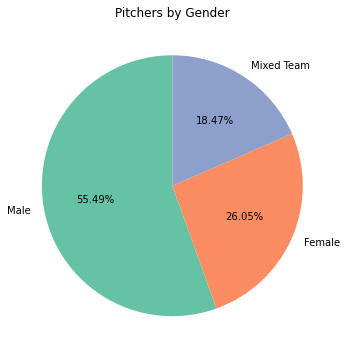

```python
# Plot pitcher gender by percentages
# Plot chart
palette_color = sns.color_palette('Set2') # set color palette
# set labels
gender_chart = gender_teams.plot.pie(labels=['Male', 'Female', 'Mixed Team'], autopct='%.2f%%', figsize=(6, 6), colors=palette_color, startangle=90)
gender_chart.yaxis.set_visible(False) # prevent column name from showing
plt.title('Pitchers by Gender')
# displaying chart
plt.show()
```

The Shark Tank show's gender distribution data shows distinct patterns in the representation of entrepreneurs: there are 234 pitches from mixed-gender teams and 703 male pitchers, a substantial majority over the 330 female pitchers. This draws attention to the gender gap in the entrepreneurial field, pointing to a higher participation rate among men and possible obstacles for female entrepreneurs using these platforms. Mixed teams demonstrate cross-gender cooperation. The gender dynamics and biases that are prevalent in the investment and entrepreneurship fields are highlighted by this data.

```python
# Filter the DataFrame to include only rows where 'Got Deal' is 1
df_deals_only = df_shark_tank_1[df_shark_tank_1['Got Deal'] == 1]

# Create a pivot table with the filtered DataFrame
pivot_table = df_deals_only.pivot_table(index='Industry', values='Total Deal Amount', aggfunc='sum')
pivot_table.sort_values(by='Total Deal Amount',ascending=False)
pivot_table.columns = ['Total Deal Amount (in $)']
pivot_table
```

| Industry | Total Deal Amount (in $) |
| --- | --- |
| Automotive | 5465000.0 |
| Business Services | 6775000.0 |
| Children/Education | 16121666.0 |
| Electronics | 1654000.0 |
| Fashion/Beauty | 28407500.0 |
| Fitness/Sports/Outdoors | 20830000.0 |
| Food and Beverage | 51201000.0 |
| Green/CleanTech | 1950000.0 |
| Health/Wellness | 17665000.0 |
| Lifestyle/Home | 37170000.0 |
| Liquor/Alcohol | 3150000.0 |
| Media/Entertainment | 7150000.0 |
| Pet Products | 7224000.0 |
| Software/Tech | 11185000.0 |
| Travel | 5850000.0 |
| Uncertain/Other | 4690000.0 |

```python
# Create bar chart on deal amount and industry
fig = px.bar(pivot_table, x=pivot_table.index, y='Total Deal Amount (in $)', # set x and y axis
        hover_data=['Total Deal Amount (in $)'], # displays amount and industry upon hovering
        labels={'pop':'Total Deal Amount (in $)'},
        height=700,width=1000) # set the size of the graph
# Change background colors to grey
fig.update_layout(plot_bgcolor='#fff')
fig.update_traces(marker_color='#537291')
fig.update_layout(
    title={'text': 'Total Deal Amount in Different Industry',
        'x':0.5,
        'xanchor': 'center'})
# Show the figure
fig.show()
```

[output not shown]

```python
# Grouping by 'Season Number' and count the number of pitches
pitches_per_season = df_shark_tank_1.groupby('Season Number')['Pitch Number'].count()
pitches_per_season
```

```
Season Number
1      64
2      36
3      60
4     103
5     116
6     116
7     116
8      96
9      96
10     92
11     96
12    100
13     96
14     87
Name: Pitch Number, dtype: int64
```

The dataset reveals variations in the number of pitches across different seasons of "Shark Tank," with the highest number of pitches occurring in Seasons 5, 6, and 7, indicating peak participation during those seasons.

```python
# Group by each season and then finding the max # of episodes for each season
max_episodes_per_season = df_shark_tank_1.groupby('Season Number')['Episode Number'].max()

# Group by season # and episode # and counting the # of pitches,
max_pitches_per_episode_per_season = df_shark_tank_1.groupby(['Season Number', 'Episode Number']).size().groupby(level=0).max()
mean_view = df_shark_tank_1.groupby(['Season Number', 'US Viewership']).size().groupby(level=0).mean()
# Creating a summary
season_summary = pd.DataFrame({
    'Max Episodes': max_episodes_per_season,
    'Mean Vieweship': mean_view
}).applymap('{:,.2f}'.format)
season_summary
```

| Season Number | Max Episodes | Mean Vieweship |
| --- | --- | --- |
| 1 | 14.00 | 4.57 |
| 2 | 9.00 | 4.00 |
| 3 | 15.00 | 4.29 |
| 4 | 26.00 | 4.48 |
| 5 | 29.00 | 4.30 |
| 6 | 29.00 | 4.64 |
| 7 | 29.00 | 4.64 |
| 8 | 24.00 | 4.57 |
| 9 | 24.00 | 4.17 |
| 10 | 23.00 | 4.60 |
| 11 | 24.00 | 4.17 |
| 12 | 25.00 | 4.17 |
| 13 | 24.00 | 4.57 |
| 14 | 22.00 | 4.35 |

# 3 **Data Preprocessing**

Summary of what has been done so far for data acquistion and data preprocessing (cleaning and transformation) :

- Acquired the data from Kaggle
- Exploratory data analysis on the two datasets
- Identified the null values in both datasets and replace them with meaningful values
- Identified their appropriate indexes
- Data transformation using regex, datetime, etc.
- Visualized some of the observations to understand the columns of dataset in a better manner
- Summarized some of the columns to identify patterns over multiple seasons

#### 3.1 Data Cleaning

```python
df_shark_tank_1.isnull().sum() # show the total number of null values per column
```

```
Season Number                            0
Season Start                             0
Season End                               0
Episode Number                           0
Pitch Number                             0
Original Air Date                        0
Startup Name                             0
Industry                                 0
Business Description                     0
Pitchers Gender                          7
Pitchers City                          772
Pitchers State                         528
Pitchers Average Age                   936
Entrepreneur Names                     495
Company Website                        758
Multiple Entrepreneurs                 427
US Viewership                            0
Original Ask Amount                      0
Original Offered Equity                  0
Valuation Requested                      0
Got Deal                                 0
Total Deal Amount                      509
Total Deal Equity                      509
Deal Valuation                         509
Number of sharks in deal               509
Investment Amount Per Shark            509
Equity Per Shark                       509
Royalty Deal                          1199
Loan                                  1222
Barbara Corcoran Investment Amount    1154
Barbara Corcoran Investment Equity    1154
Mark Cuban Investment Amount          1044
Mark Cuban Investment Equity          1044
Lori Greiner Investment Amount        1075
Lori Greiner Investment Equity        1075
Robert Herjavec Investment Amount     1153
Robert Herjavec Investment Equity     1153
Daymond John Investment Amount        1163
Daymond John Investment Equity        1163
Kevin O Leary Investment Amount       1157
Kevin O Leary Investment Equity       1157
Guest Investment Amount               1169
Guest Investment Equity               1169
Guest Name                            1169
Barbara Corcoran Present               376
Mark Cuban Present                     373
Lori Greiner Present                   373
Robert Herjavec Present                377
Daymond John Present                   376
Kevin O Leary Present                  376
dtype: int64
```

##### Typecasting a few columns

```python
# Change columns to float type
df_shark_tank_1['Guest Investment Amount'] = df_shark_tank_1['Guest Investment Amount'].astype(float)
df_shark_tank_1['Guest Investment Equity'] = df_shark_tank_1['Guest Investment Equity'].astype(float)

# Change columns to datetime type
df_shark_tank_1["Season Start"]=pd.to_datetime(df_shark_tank_1["Season Start"])
df_shark_tank_1["Season End"]=pd.to_datetime(df_shark_tank_1["Season End"])
df_shark_tank_1["Original Air Date"]=pd.to_datetime(df_shark_tank_1["Original Air Date"])

# Change columns to integer type
df_shark_tank_1['Season Number'] = df_shark_tank_1['Season Number'].astype(pd.Int32Dtype())
df_shark_tank_1['Episode Number'] = df_shark_tank_1['Episode Number'].astype(pd.Int32Dtype())
df_shark_tank_1['Pitch Number'] = df_shark_tank_1['Pitch Number'].astype(pd.Int32Dtype())

# Change columns to string type
df_shark_tank_1['Startup Name'] = df_shark_tank_1['Startup Name'].astype(str)
df_shark_tank_1['Industry'] = df_shark_tank_1['Industry'].astype(str)
df_shark_tank_1['Business Description'] = df_shark_tank_1['Business Description'].astype(str)
df_shark_tank_1['Multiple Entrepreneurs'] = df_shark_tank_1['Multiple Entrepreneurs'].astype(pd.Int32Dtype()) # integer type
```

##### Fill or drop all NaNs with 0 or appropriate text value for clarification

```python
# since this column has only 7 rows with null values, it makes sense to drop those obsevations
df_shark_tank_1.dropna(subset=['Pitchers Gender'],inplace=True)

# dropping the columns 'Royalty Deal' and 'Loan' since they are not relevant to our analysis
df_shark_tank_1.drop(['Royalty Deal','Loan'], axis=1, inplace=True)
```

```python
# filling columns with unknown which have null values
columns_to_fill_unknown=['Pitchers City', 'Pitchers State', 'Pitchers Average Age','Entrepreneur Names', 'Guest Name', 'Company Website']

# filling columns with value as 0.0 which have null values
columns_to_fill_0=['Multiple Entrepreneurs', 'Total Deal Amount', 'Total Deal Equity',
               'Deal Valuation', 'Number of sharks in deal', 'Investment Amount Per Shark', 'Equity Per Shark',
               'Barbara Corcoran Investment Amount', 'Barbara Corcoran Investment Equity', 'Mark Cuban Investment Amount',
               'Mark Cuban Investment Equity', 'Lori Greiner Investment Amount', 'Lori Greiner Investment Equity',
               'Robert Herjavec Investment Amount','Robert Herjavec Investment Equity', 'Daymond John Investment Amount',
               'Daymond John Investment Equity', 'Kevin O Leary Investment Amount', 'Kevin O Leary Investment Equity',
               'Guest Investment Amount', 'Guest Investment Equity', 'Barbara Corcoran Present', 'Mark Cuban Present',
               'Lori Greiner Present', 'Robert Herjavec Present', 'Daymond John Present', 'Kevin O Leary Present']
```

Creating a new dataframe since df.apply cannot be applied to the same dataframe.

```python
# filling null values
df_st1=df_shark_tank_1.apply(lambda x: x.fillna(0.0) if x.name in columns_to_fill_0 else x.fillna('Unknown') if x.name in columns_to_fill_unknown else x)
df_st1.head()
```

|  | Season Number | Season Start | Season End | Episode Number | Pitch Number | Original Air Date | Startup Name | Industry | Business Description | Pitchers Gender | ... | Kevin O Leary Investment Equity | Guest Investment Amount | Guest Investment Equity | Guest Name | Barbara Corcoran Present | Mark Cuban Present | Lori Greiner Present | Robert Herjavec Present | Daymond John Present | Kevin O Leary Present |
| --- | --- | --- | --- | --- | --- | --- | --- | --- | --- | --- | --- | --- | --- | --- | --- | --- | --- | --- | --- | --- | --- |
| 0 | 1 | 2009-08-09 | 2010-02-05 | 1 | 1 | 2009-08-09 | AvaTheElephant | Health/Wellness | Ava The Elephant - Baby and Child Care | Female | ... | 0.0 | 0.0 | 0.0 | Unknown | 1.0 | 0.0 | 0.0 | 1.0 | 1.0 | 1.0 |
| 1 | 1 | 2009-08-09 | 2010-02-05 | 1 | 2 | 2009-08-09 | Mr.Tod'sPieFactory | Food and Beverage | Mr. Tod's Pie Factory - Specialty Food | Male | ... | 0.0 | 0.0 | 0.0 | Unknown | 1.0 | 0.0 | 0.0 | 1.0 | 1.0 | 1.0 |
| 2 | 1 | 2009-08-09 | 2010-02-05 | 1 | 3 | 2009-08-09 | Wispots | Business Services | Wispots - Consumer Services | Male | ... | 0.0 | 0.0 | 0.0 | Unknown | 1.0 | 0.0 | 0.0 | 1.0 | 1.0 | 1.0 |
| 3 | 1 | 2009-08-09 | 2010-02-05 | 1 | 4 | 2009-08-09 | CollegeFoxesPackingBoxes | Lifestyle/Home | College Foxes Packing Boxes - Consumer Services | Male | ... | 0.0 | 0.0 | 0.0 | Unknown | 1.0 | 0.0 | 0.0 | 1.0 | 1.0 | 1.0 |
| 4 | 1 | 2009-08-09 | 2010-02-05 | 1 | 5 | 2009-08-09 | IonicEar | Software/Tech | Ionic Ear - Novelties | Male | ... | 0.0 | 0.0 | 0.0 | Unknown | 1.0 | 0.0 | 0.0 | 1.0 | 1.0 | 1.0 |

5 rows × 48 columns

```python
df_shark_tank_2.isnull().sum() # show the total number of null values per column
```

```
Season_Epi_code                  0
Pitched_Business_Identifier      0
Pitched_Business_Desc            0
Deal_Status                      0
Deal_Shark                     323
dtype: int64
```

```python
df_shark_tank_2['Deal_Shark'].fillna('No Deal Made', inplace=True)
```

#### 3.2 Data Transformation

Since each business/startup has a unique and creative name, we set it as the index of the dataframe.

```python
# Setting the index to Startup Name
df_st1.set_index(['Startup Name'], inplace=True)
df_st1.head()
```

| Startup Name | Season Number | Season Start | Season End | Episode Number | Pitch Number | Original Air Date | Industry | Business Description | Pitchers Gender | Pitchers City | ... | Kevin O Leary Investment Equity | Guest Investment Amount | Guest Investment Equity | Guest Name | Barbara Corcoran Present | Mark Cuban Present | Lori Greiner Present | Robert Herjavec Present | Daymond John Present | Kevin O Leary Present |
| --- | --- | --- | --- | --- | --- | --- | --- | --- | --- | --- | --- | --- | --- | --- | --- | --- | --- | --- | --- | --- | --- |
| AvaTheElephant | 1 | 2009-08-09 | 2010-02-05 | 1 | 1 | 2009-08-09 | Health/Wellness | Ava The Elephant - Baby and Child Care | Female | Atlanta | ... | 0.0 | 0.0 | 0.0 | Unknown | 1.0 | 0.0 | 0.0 | 1.0 | 1.0 | 1.0 |
| Mr.Tod'sPieFactory | 1 | 2009-08-09 | 2010-02-05 | 1 | 2 | 2009-08-09 | Food and Beverage | Mr. Tod's Pie Factory - Specialty Food | Male | Somerset | ... | 0.0 | 0.0 | 0.0 | Unknown | 1.0 | 0.0 | 0.0 | 1.0 | 1.0 | 1.0 |
| Wispots | 1 | 2009-08-09 | 2010-02-05 | 1 | 3 | 2009-08-09 | Business Services | Wispots - Consumer Services | Male | Cary | ... | 0.0 | 0.0 | 0.0 | Unknown | 1.0 | 0.0 | 0.0 | 1.0 | 1.0 | 1.0 |
| CollegeFoxesPackingBoxes | 1 | 2009-08-09 | 2010-02-05 | 1 | 4 | 2009-08-09 | Lifestyle/Home | College Foxes Packing Boxes - Consumer Services | Male | Tampa | ... | 0.0 | 0.0 | 0.0 | Unknown | 1.0 | 0.0 | 0.0 | 1.0 | 1.0 | 1.0 |
| IonicEar | 1 | 2009-08-09 | 2010-02-05 | 1 | 5 | 2009-08-09 | Software/Tech | Ionic Ear - Novelties | Male | St. Paul | ... | 0.0 | 0.0 | 0.0 | Unknown | 1.0 | 0.0 | 0.0 | 1.0 | 1.0 | 1.0 |

5 rows × 47 columns

```python
# Create a copy of dataset 2 and extract the text columns
df_shark_tank_3 = df_shark_tank_2.loc[:,('Pitched_Business_Identifier','Pitched_Business_Desc')]
# Convert all the company name to lower case to match with dataset 1
df_shark_tank_3['Pitched_Business_Identifier_m'] = df_shark_tank_2['Pitched_Business_Identifier'].str.lower()
# Remove all the white space in company names
df_shark_tank_3['Name'] = df_shark_tank_3['Pitched_Business_Identifier_m'].str.replace('\s','',regex=True)
df_shark_tank_3.head()
```

|  | Pitched_Business_Identifier | Pitched_Business_Desc | Pitched_Business_Identifier_m | Name |
| --- | --- | --- | --- | --- |
| 0 | Bridal Buddy | a functional slip worn under a wedding gown th... | bridal buddy | bridalbuddy |
| 1 | Laid Brand | hair-care products made with pheromones . Laid... | laid brand | laidbrand |
| 2 | Rocketbook | a notebook that can scan contents to cloud ser... | rocketbook | rocketbook |
| 3 | Wine & Design | painting classes with wine served . Wine & Des... | wine & design | wine&design |
| 4 | Peoples Design | a mixing bowl with a built-in scoop . Peoples ... | peoples design | peoplesdesign |

Convert the company name in both dataset to lower case as the cloumn to join on.

```python
# Convert all the company name to lower case to match with dataset 2
df_st1['Name'] = df_st1.index.str.lower()
# Perform left merge on the two dataset, preserve the data in dataset 1
df_shark_tank_merged = df_st1.merge(df_shark_tank_3,how='left',on='Name')
df_shark_tank_merged.head()
```

|  | Season Number | Season Start | Season End | Episode Number | Pitch Number | Original Air Date | Industry | Business Description | Pitchers Gender | Pitchers City | ... | Barbara Corcoran Present | Mark Cuban Present | Lori Greiner Present | Robert Herjavec Present | Daymond John Present | Kevin O Leary Present | Name | Pitched_Business_Identifier | Pitched_Business_Desc | Pitched_Business_Identifier_m |
| --- | --- | --- | --- | --- | --- | --- | --- | --- | --- | --- | --- | --- | --- | --- | --- | --- | --- | --- | --- | --- | --- |
| 0 | 1 | 2009-08-09 | 2010-02-05 | 1 | 1 | 2009-08-09 | Health/Wellness | Ava The Elephant - Baby and Child Care | Female | Atlanta | ... | 1.0 | 0.0 | 0.0 | 1.0 | 1.0 | 1.0 | avatheelephant | Ava the Elephant | (Emmy the Elephant during show, trademarked a... | ava the elephant |
| 1 | 1 | 2009-08-09 | 2010-02-05 | 1 | 2 | 2009-08-09 | Food and Beverage | Mr. Tod's Pie Factory - Specialty Food | Male | Somerset | ... | 1.0 | 0.0 | 0.0 | 1.0 | 1.0 | 1.0 | mr.tod'spiefactory | Mr. Tod's Pie Factory | a pie company | mr. tod's pie factory |
| 2 | 1 | 2009-08-09 | 2010-02-05 | 1 | 3 | 2009-08-09 | Business Services | Wispots - Consumer Services | Male | Cary | ... | 1.0 | 0.0 | 0.0 | 1.0 | 1.0 | 1.0 | wispots | Wispots | an electronic hand-held device for waiting roo... | wispots |
| 3 | 1 | 2009-08-09 | 2010-02-05 | 1 | 4 | 2009-08-09 | Lifestyle/Home | College Foxes Packing Boxes - Consumer Services | Male | Tampa | ... | 1.0 | 0.0 | 0.0 | 1.0 | 1.0 | 1.0 | collegefoxespackingboxes | College Foxes Packing Boxes | a packing and organizing service based on an a... | college foxes packing boxes |
| 4 | 1 | 2009-08-09 | 2010-02-05 | 1 | 5 | 2009-08-09 | Software/Tech | Ionic Ear - Novelties | Male | St. Paul | ... | 1.0 | 0.0 | 0.0 | 1.0 | 1.0 | 1.0 | ionicear | Ionic Ear | an implantable Bluetooth device requiring surg... | ionic ear |

5 rows × 51 columns

Since the longer pithes discription in the second dataset only contains Business Description information from season 1-8, we choose to combine the short Business Description from dataset one together with the longer description to one column.

```python
# Merge the long description with the shorter discription into one column
df_shark_tank_merged['Business Description']=df_shark_tank_merged['Business Description'].fillna('').map(str)+'-'+df_shark_tank_merged['Pitched_Business_Desc'].fillna('').map(str)
df_shark_tank_merged['Name'] = df_shark_tank_merged['Pitched_Business_Identifier'].str.replace('\s','',regex=True)
#Setting the index of the dataframe as Name
df_shark_tank_merged.set_index(['Name'],inplace=True)
df_shark_tank_merged.head()
```

| Name | Season Number | Season Start | Season End | Episode Number | Pitch Number | Original Air Date | Industry | Business Description | Pitchers Gender | Pitchers City | ... | Guest Name | Barbara Corcoran Present | Mark Cuban Present | Lori Greiner Present | Robert Herjavec Present | Daymond John Present | Kevin O Leary Present | Pitched_Business_Identifier | Pitched_Business_Desc | Pitched_Business_Identifier_m |
| --- | --- | --- | --- | --- | --- | --- | --- | --- | --- | --- | --- | --- | --- | --- | --- | --- | --- | --- | --- | --- | --- |
| AvatheElephant | 1 | 2009-08-09 | 2010-02-05 | 1 | 1 | 2009-08-09 | Health/Wellness | Ava The Elephant - Baby and Child Care- (Emmy ... | Female | Atlanta | ... | Unknown | 1.0 | 0.0 | 0.0 | 1.0 | 1.0 | 1.0 | Ava the Elephant | (Emmy the Elephant during show, trademarked a... | ava the elephant |
| Mr.Tod'sPieFactory | 1 | 2009-08-09 | 2010-02-05 | 1 | 2 | 2009-08-09 | Food and Beverage | Mr. Tod's Pie Factory - Specialty Food-a pie c... | Male | Somerset | ... | Unknown | 1.0 | 0.0 | 0.0 | 1.0 | 1.0 | 1.0 | Mr. Tod's Pie Factory | a pie company | mr. tod's pie factory |
| Wispots | 1 | 2009-08-09 | 2010-02-05 | 1 | 3 | 2009-08-09 | Business Services | Wispots - Consumer Services-an electronic hand... | Male | Cary | ... | Unknown | 1.0 | 0.0 | 0.0 | 1.0 | 1.0 | 1.0 | Wispots | an electronic hand-held device for waiting roo... | wispots |
| CollegeFoxesPackingBoxes | 1 | 2009-08-09 | 2010-02-05 | 1 | 4 | 2009-08-09 | Lifestyle/Home | College Foxes Packing Boxes - Consumer Service... | Male | Tampa | ... | Unknown | 1.0 | 0.0 | 0.0 | 1.0 | 1.0 | 1.0 | College Foxes Packing Boxes | a packing and organizing service based on an a... | college foxes packing boxes |
| IonicEar | 1 | 2009-08-09 | 2010-02-05 | 1 | 5 | 2009-08-09 | Software/Tech | Ionic Ear - Novelties-an implantable Bluetooth... | Male | St. Paul | ... | Unknown | 1.0 | 0.0 | 0.0 | 1.0 | 1.0 | 1.0 | Ionic Ear | an implantable Bluetooth device requiring surg... | ionic ear |

5 rows × 50 columns

**The team has recently started working on the data analysis part involving the 5 questions. The below mentioned solution for Question 1 is not finalized yet. The team is following the timeline for the data analysis & visualization phase.**

# Question 1 :

**Can we identify temporal patterns in pitch success on the show and how do they evolve over the seasons, including viewership trends?**

```python
#QUESTION1

# Converting 'Original Air Date' to datetime format and extracting month and year
df_st1['Original Air Date'] = pd.to_datetime(df_st1['Original Air Date'])
df_st1['Month'] = df_st1['Original Air Date'].dt.month
df_st1['Year'] = df_st1['Original Air Date'].dt.year

# Finding if a deal has been secured
df_st1['Success'] = df_st1['Got Deal'] == 1

# Creating a variable num_to_percentage that will be used to convert the rate into percentage
num_to_percentage = 100

# Group by month and calculate success rate
monthly_success_rate = df_st1.groupby('Month')['Success'].mean()*num_to_percentage

# Group by season and calculate success rate
seasonal_success_rate = df_st1.groupby('Season Number')['Success'].mean()*num_to_percentage
```

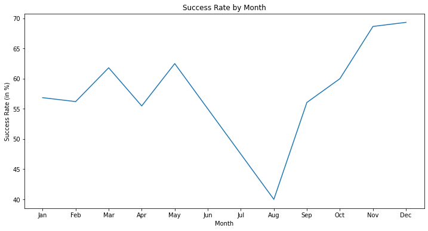

```python
# Plotting the success rate by month
plt.figure(figsize=(12,6))

plt.plot(monthly_success_rate.index, monthly_success_rate.values)
plt.title('Success Rate by Month')
plt.xlabel('Month')
plt.ylabel('Success Rate (in %)')
plt.xticks(range(1, 13), ['Jan', 'Feb', 'Mar', 'Apr', 'May', 'Jun', 'Jul', 'Aug', 'Sep', 'Oct', 'Nov', 'Dec'])
plt.show()
```

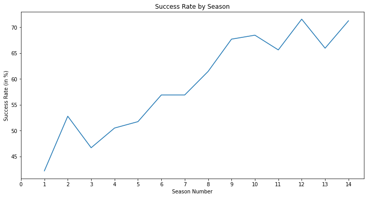

```python
# Plotting the success rate by season
plt.figure(figsize=(12, 6))
plt.plot(seasonal_success_rate.index, seasonal_success_rate.values)
plt.title('Success Rate by Season')
plt.xlabel('Season Number')
plt.xticks(range(0, 15), ['0','1', '2', '3', '4', '5', '6', '7', '8', '9', '10', '11', '12', '13', '14'])
plt.ylabel('Success Rate (in %)')
plt.show()
```

This graph showing the success rate by season on the show indicates an upward trajectory, with a higher percentage of pitches securing deals in later seasons of the show. This increase suggests an increase in entrepreneurs and also the quality of their presentations have gotten more effective over time, or that the investors are more inclined to engage in deals with entrepreneurs indicating a rise in confidence as the series evolves. The variations seen in certain seasons reflect the dynamic nature of investment and the ever-changing strategies of both the pitchers and sharks. The data demonstrates a clear enhancement in the show’s capacity to facilitate successful investments as seasons advance.

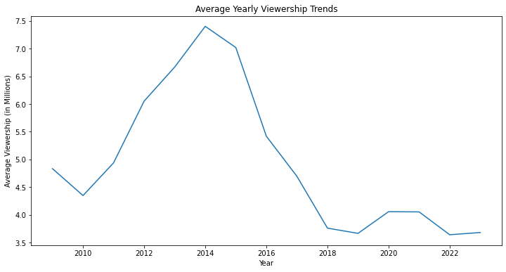

```python
# Grouping by year and calculate average viewership
yearly_viewership = df_st1.groupby('Year')['US Viewership'].mean()

# Plotting the viewership trend over the years
plt.figure(figsize=(12, 6))
plt.plot(yearly_viewership.index, yearly_viewership.values)
plt.title('Average Yearly Viewership Trends')
plt.xlabel('Year')
#plt.xticks(range(0, 13), ['2009','2010', '2011', '2012', '2013', '2014', '2015', '2016', '2017', '2018', '2019', '2020', '2021', '2022', '2023'])
plt.ylabel('Average Viewership (in Millions)')
plt.show()
```

# **Question 2**

Are there statistically significant co-investment patterns among the sharks, revealing insights into their investment strategies and price discrimination?

```python
#Finding all companies that got investment deals
df_deal=df_st1[df_st1['Got Deal']==1]
```

```python
#Descriptive Statistics for Investments by Investor
df_desc_stat=df_st1[['Barbara Corcoran Investment Amount','Mark Cuban Investment Amount','Lori Greiner Investment Amount','Robert Herjavec Investment Amount','Daymond John Investment Amount','Kevin O Leary Investment Amount']].describe()
df_desc_stat.applymap('{:,.2f}'.format)
```

|  | Barbara Corcoran Investment Amount | Mark Cuban Investment Amount | Lori Greiner Investment Amount | Robert Herjavec Investment Amount | Daymond John Investment Amount | Kevin O Leary Investment Amount |
| --- | --- | --- | --- | --- | --- | --- |
| count | 1,267.00 | 1,267.00 | 1,267.00 | 1,267.00 | 1,267.00 | 1,267.00 |
| mean | 13,843.73 | 46,585.90 | 33,656.93 | 27,937.91 | 15,982.50 | 21,975.14 |
| std | 55,816.46 | 154,593.26 | 113,865.97 | 186,836.30 | 101,840.21 | 114,333.14 |
| min | 0.00 | 0.00 | 0.00 | 0.00 | 0.00 | 0.00 |
| 25% | 0.00 | 0.00 | 0.00 | 0.00 | 0.00 | 0.00 |
| 50% | 0.00 | 0.00 | 0.00 | 0.00 | 0.00 | 0.00 |
| 75% | 0.00 | 0.00 | 0.00 | 0.00 | 0.00 | 0.00 |
| max | 700,000.00 | 2,000,000.00 | 1,175,000.00 | 5,000,000.00 | 3,000,000.00 | 2,500,000.00 |

```python
#Finding All Deals Invested by a particular investor
df_barb=df_deal[df_deal['Barbara Corcoran Investment Amount']!=0.0]
df_mark=df_deal[df_deal['Mark Cuban Investment Amount']!=0.0]
df_lori=df_deal[df_deal['Lori Greiner Investment Amount']!=0.0]
df_rob=df_deal[df_deal['Robert Herjavec Investment Amount']!=0.0]
df_kev=df_deal[df_deal['Daymond John Investment Amount']!=0.0]
df_daym=df_deal[df_deal['Kevin O Leary Investment Amount']!=0.0]
```

```python
#Creating sets to find what companies an investor has invested in
inv_barb=set(df_barb.index)
inv_mark=set(df_mark.index)
inv_lori=set(df_lori.index)
inv_rob=set(df_rob.index)
inv_kev=set(df_kev.index)
inv_daym=set(df_daym.index)
```

```python
#Number of companies each investor has invested in
print(f'Number of companies Barbara Corcoran Invested in: {len(inv_barb)}')
print(f'Number of companies Mark Cuban Invested in: {len(inv_mark)}')
print(f'Number of companies Lori Greiner Invested in: {len(inv_lori)}')
print(f'Number of companies Robert Herjavec Invested in: {len(inv_rob)}')
print(f'Number of companies Daymond John Invested in: {len(inv_daym)}')
print(f'Number of companies Kevin O Leary Invested in: {len(inv_kev)}')
```

[output not shown]

```python
#Co investment of Barbara and Lori
inv_barb&inv_lori
```

```
{'Eyewris', 'HoldYourHaunches'}
```

```python
#Correlation between investments by Barbara and Lori
```

[output not shown]

# Question 3:

Can we analyze trends in pitchers on the show to identify sectors with the highest capital raised and assess how investment trends impact the business pitches?

```python
import plotly
import plotly.graph_objects as go
df_deal = df_st1[df_st1['Got Deal'] == 1]
avg_values = df_deal.groupby('Industry').mean().reset_index()
avg_values.sort_values(by=['Total Deal Amount'],ascending=False,inplace=True)
avg_sharks = avg_values[['Industry','Barbara Corcoran Investment Amount','Barbara Corcoran Investment Equity',
            'Mark Cuban Investment Amount','Mark Cuban Investment Equity',
            'Lori Greiner Investment Amount','Lori Greiner Investment Equity',
            'Robert Herjavec Investment Amount','Robert Herjavec Investment Equity',
            'Daymond John Investment Amount','Daymond John Investment Equity',
            'Kevin O Leary Investment Amount','Kevin O Leary Investment Equity']]
avg_values
```

|  | Industry | Season Number | Episode Number | Pitch Number | Multiple Entrepreneurs | US Viewership | Original Ask Amount | Original Offered Equity | Valuation Requested | Got Deal | ... | Guest Investment Equity | Barbara Corcoran Present | Mark Cuban Present | Lori Greiner Present | Robert Herjavec Present | Daymond John Present | Kevin O Leary Present | Month | Year | Success |
| --- | --- | --- | --- | --- | --- | --- | --- | --- | --- | --- | --- | --- | --- | --- | --- | --- | --- | --- | --- | --- | --- |
| 14 | Travel | 4.6 | 15.0 | 306.2 | 0.6 | 6.732000 | 1.150000e+06 | 22.000000 | 3.306667e+06 | 1.0 | ... | 0.000000 | 0.400000 | 0.800000 | 0.800000 | 1.000000 | 0.800000 | 1.000000 | 5.000000 | 2013.400000 | 1.0 |
| 10 | Liquor/Alcohol | 7.25 | 7.5 | 545.0 | 0.0 | 5.247500 | 4.125000e+05 | 7.250000 | 8.500000e+06 | 1.0 | ... | 0.000000 | 0.750000 | 1.000000 | 0.750000 | 0.750000 | 0.750000 | 1.000000 | 8.000000 | 2015.500000 | 1.0 |
| 11 | Media/Entertainment | 6.866667 | 13.2 | 531.8 | 0.266667 | 5.428000 | 4.300000e+05 | 10.666667 | 5.088889e+06 | 1.0 | ... | 3.000000 | 0.533333 | 0.933333 | 0.666667 | 0.866667 | 0.666667 | 0.866667 | 5.666667 | 2015.533333 | 1.0 |
| 8 | Health/Wellness | 9.179487 | 11.897436 | 761.666667 | 0.358974 | 4.546923 | 4.105128e+05 | 10.961538 | 7.137927e+06 | 1.0 | ... | 0.538462 | 0.307692 | 0.487179 | 0.410256 | 0.487179 | 0.333333 | 0.435897 | 5.743590 | 2017.769231 | 1.0 |
| 0 | Automotive | 9.0 | 14.846154 | 754.153846 | 0.538462 | 4.378462 | 1.957692e+05 | 12.076923 | 3.701282e+06 | 1.0 | ... | 0.769231 | 0.384615 | 0.615385 | 0.538462 | 0.615385 | 0.461538 | 0.615385 | 5.000000 | 2017.769231 | 1.0 |
| 15 | Uncertain/Other | 10.583333 | 15.5 | 913.583333 | 0.333333 | 4.012500 | 3.283333e+05 | 13.166667 | 3.708333e+06 | 1.0 | ... | 0.000000 | 0.250000 | 0.333333 | 0.250000 | 0.166667 | 0.250000 | 0.416667 | 6.750000 | 2019.250000 | 1.0 |
| 1 | Business Services | 10.333333 | 13.722222 | 875.777778 | 0.555556 | 4.347778 | 3.673889e+05 | 10.683333 | 5.539418e+06 | 1.0 | ... | 3.055556 | 0.222222 | 0.333333 | 0.277778 | 0.166667 | 0.277778 | 0.333333 | 6.388889 | 2018.944444 | 1.0 |
| 7 | Green/CleanTech | 6.333333 | 16.833333 | 480.666667 | 0.166667 | 6.371667 | 3.250000e+05 | 14.500000 | 3.394048e+06 | 1.0 | ... | 3.333333 | 0.500000 | 1.000000 | 1.000000 | 0.500000 | 0.500000 | 0.833333 | 5.666667 | 2015.000000 | 1.0 |
| 13 | Software/Tech | 7.457143 | 10.2 | 582.085714 | 0.285714 | 5.242571 | 2.540000e+05 | 10.985714 | 3.445181e+06 | 1.0 | ... | 0.142857 | 0.514286 | 0.771429 | 0.685714 | 0.657143 | 0.400000 | 0.771429 | 6.828571 | 2015.885714 | 1.0 |
| 6 | Food and Beverage | 8.642424 | 12.515152 | 707.50303 | 0.357576 | 4.996121 | 2.816970e+05 | 12.487879 | 3.586903e+06 | 1.0 | ... | 3.606061 | 0.369697 | 0.563636 | 0.466667 | 0.509091 | 0.381818 | 0.581818 | 5.751515 | 2017.254545 | 1.0 |
| 5 | Fitness/Sports/Outdoors | 7.382353 | 12.720588 | 589.176471 | 0.294118 | 5.239412 | 2.632353e+05 | 14.000000 | 3.305762e+06 | 1.0 | ... | 5.308824 | 0.397059 | 0.720588 | 0.588235 | 0.676471 | 0.588235 | 0.720588 | 6.220588 | 2015.955882 | 1.0 |
| 3 | Electronics | 6.833333 | 15.833333 | 536.333333 | 0.666667 | 5.108333 | 2.756667e+05 | 15.166667 | 3.173504e+06 | 1.0 | ... | 0.000000 | 0.666667 | 0.666667 | 0.333333 | 0.666667 | 0.333333 | 0.666667 | 5.000000 | 2015.666667 | 1.0 |
| 9 | Lifestyle/Home | 9.3 | 11.94 | 768.053333 | 0.32 | 4.880467 | 2.186000e+05 | 13.090000 | 2.877527e+06 | 1.0 | ... | 1.386667 | 0.320000 | 0.546667 | 0.520000 | 0.506667 | 0.306667 | 0.540000 | 6.533333 | 2017.826667 | 1.0 |
| 4 | Fashion/Beauty | 7.95082 | 12.942623 | 642.836066 | 0.286885 | 5.045246 | 2.086885e+05 | 14.790984 | 2.321469e+06 | 1.0 | ... | 1.526639 | 0.360656 | 0.655738 | 0.549180 | 0.680328 | 0.491803 | 0.696721 | 5.696721 | 2016.606557 | 1.0 |
| 12 | Pet Products | 8.344828 | 14.103448 | 690.241379 | 0.137931 | 4.924138 | 2.292759e+05 | 12.862069 | 3.607572e+06 | 1.0 | ... | 1.810345 | 0.275862 | 0.724138 | 0.689655 | 0.620690 | 0.551724 | 0.793103 | 5.655172 | 2017.000000 | 1.0 |
| 2 | Children/Education | 7.767123 | 12.39726 | 622.917808 | 0.315068 | 5.385479 | 1.999315e+05 | 13.469863 | 2.511211e+06 | 1.0 | ... | 0.937671 | 0.397260 | 0.684932 | 0.643836 | 0.630137 | 0.438356 | 0.739726 | 5.328767 | 2016.383562 | 1.0 |

16 rows × 39 columns

```python
fig3 = go.Figure()
investors = ['Barbara Corcoran', 'Mark Cuban', 'Lori Greiner', 'Robert Herjavec', 'Daymond John', 'Kevin O Leary']
fig3.update_layout(updatemenus=[dict(buttons=list([dict(label='Deal Amount',method='update',
                       args=[{'y': [avg_sharks[f'{investor} Investment Amount'] for investor in investors],
                        'x':[avg_sharks['Industry']],
                        'type': 'bar',
                        'name': investors,
                        'barmode': 'stack'},
                        {'title': 'Average Deal Amount of each investor vs Industry'}]),
                    dict(label='Deal Equity',method='update',
                       args=[{'y': [avg_sharks[f'{investor} Investment Equity'] for investor in investors],
                        'x':[avg_sharks['Industry']],
                        'type': 'bar',
                        'name': investors,
                        'barmode': 'stack'},
                        {'title': 'Average Deal Equity of each investor vs Industry'}])]),
          direction='down',
          showactive=True,
          x=0.7,
          y=1.1,
          xanchor='left',
          yanchor='top'
        ),
    ]
)

for investor in investors:
    fig3.add_trace(go.Bar(x=avg_sharks['Industry'], y=avg_sharks[f'{investor} Investment Amount'],name=investor))
fig3.update_layout(title='Average Deal Amount vs Industry',xaxis_tickangle=90, plot_bgcolor='white',width=1000,height=800)
fig3.update_layout(barmode='stack')
fig3.show()
```

[output not shown]

# **Team Members**

1. Aswin Ramesh
2. Harshil Patel
3. Omonegho Ugheoke
4. Huan Gao
5. Ajith Adithya R K
6. Siddharth Kulkarni
7. Kunal Gulati
8. Krishang Parakh

Under the guidance of : **Prof. John Bono**

**PENDING ITEMS:**  
*December 4 Deadline !!!*

(1) Complete Question 2  
(2) Questions 3,4,5 - MAX of 6 visualizations for all 5 questions ! Each analysis needs to tell a story and serve a purpose  
(3) Markdowns + explanation why Data Analysis is a heavier grading requirement  
(4) Conclusion - generalizability and notebook quality included  
(5) Rewrite Introduction  
(6) Report (60 points) - cite sources, figures, tables, references - review the guidelines below  
(7) PPT (10 points, 12-15 mins) - review the STRICT guidelines below  
(8) Prepare for questions from Prof. Bono's end during the presentation ! (hack)

**DIVISION OF TASKS:**

Harshil - PPT  
Aswin - Q4  
Joyce - Q3  
Omonegho - Q5  
Ajith - complete Q2, Conclusion  
Krishang, Sid, Kunal - Report + explain why data analysis has heavier grading + Introduction + Handle visualizations, decide which are to be showcased during presentation + focusing on the story / purpose / usefullness of this project & analysis + markdowns!  
PLEASE READ THE BELOW MENTIONED RUBRIC FOR REPORT AND SHOWCASE BELOW BEFORE STARTING TASKS

**Project Report**  
Each group will submit one client-ready, written report in the form of a single, well-organized, annotated Jupyter Notebook and HTML export.

The report must include the following sections in sufficient detail:

Introduction (6 points) An introduction that sets the stage for your analysis, describes the questions you attempted to answer at a high level, explains why the answers to the question matter, and provides a detailed description of the data set(s) and how they were acquired. Do not just copy the introduction from your proposal/project update. The final report introduction must be based on the report you are presenting. Choice for Heavier Grading on Data Processing or Data Analysis (1 point) A description of whether your project should be graded more heavily on data processing or data analysis. You must choose one option or the other. If you select data processing, clearly describe why you believe the work you did goes above and beyond basic data processing needed for most data sets. If you select data analysis, clearly describe why you believe the work you did goes above and beyond basic data analysis needed to answer your questions. Data Processing (15 or 20 points) **A description and presentation of the tasks required to process (i.e., clean, transform, enhance, etc.) the data and prepare it for analysis. Data Analysis (15 or 20 points)** A description and presentation of your analysis, to include specific questions and any relevant output, tables, and figures aimed at addressing the answers to the questions. Conclusions (5 points) Summarize your findings and explain why the results are meaningful. Notebook Quality (10 points) Points are reserved for evaluating the quality of your notebook, including the organization, formatting, and appropriate use of markdown cells to document your process and analysis in a clear to understand format. Make sure your Notebook starts at cell 1 and then continues contiguously. There must be no numeric gaps in your cells. Generalizability (3 points) Points are reserved for evaluating the generalizability of your findings and intellectual contribution of your project. ** Extra Details on Data Processing vs. Data Analysis

Projects that are more Data Processing Focused:

(20 points for Data Processing / 15 points for Data Analysis) Must have a minimum of three analyses (each data visualization or model output counts as one analysis) and a maximum of four. Do not include more than the maximum number of analyses. Projects that are more Data Analysis Focused:

(15 points for Data Processing / 20 points for Data Analysis) Must have a minimum of five analyses (each data visualization or model output counts as one analysis) and a maximum of six. Do not include more than the maximum number of analyses. Please keep in mind (always) high quantity != high quality. What story are you trying to tell with your analyses? And does each analysis serve a purpose?

You do not need to (and must not) output every step of the process, but a sufficient amount of text, output, tables, and figures needs to be produced to adequately describe the processing and analysis of the data. The quality of your code itself will be factored into the processing and analysis portions of your grade. All of the aforementioned aspects of the project must be addressed to an appropriate level of detail. Reports must be written as clearly and concisely as possible, with minimal grammatical and formatting errors. Any sources used in the report must be cited in the text and listed in a Reference section at the end of the report (any format is acceptable, but APA is preferred). Figures and tables must be used in the report whenever they are appropriate and must be referenced in the associated text.

Submit BOTH a Jupyter Notebook and an exported HTML file. Test your HTML file is working as you expect it.